# FigureYa71ssGSEA_update

小丫画图出品

2019-9-4

欢迎关注“小丫画图”公众号，同名知识星球等你加入

小丫微信: epigenomics E-mail: figureya@126.com

作者：夏至

小丫编辑校验

## 需求描述

输入TCGA数据，用原文的方法计算，原图复现。

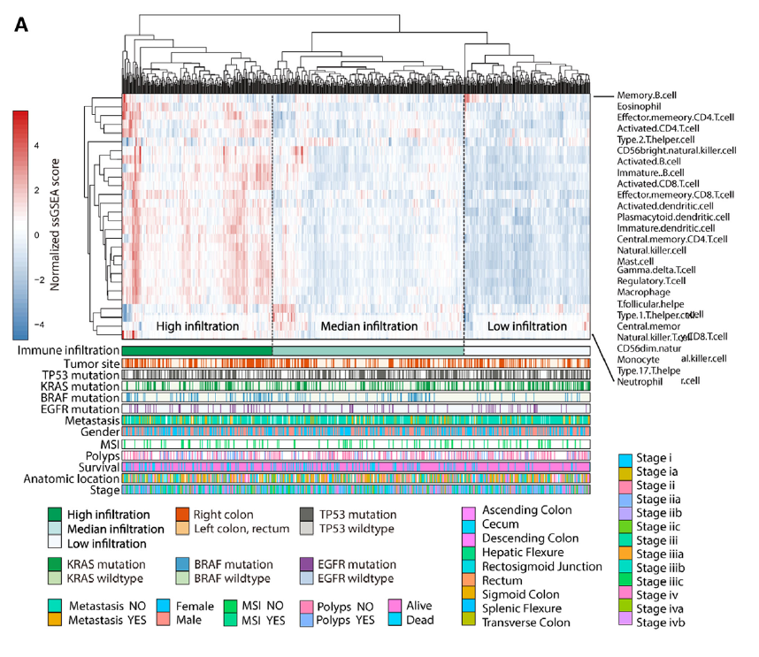

出自https://doi.org/10.3389/fimmu.2018.01578

## 应用场景

关于量化浸润免疫细胞，2018年发表在Cancer Immunol Immunother中的一篇综述概况了目前所用的几种方法：[Quantifying tumor-infiltrating immune cells from transcriptomics data](https://link.springer.com/article/10.1007%2Fs00262-018-2150-z)。

ssGSEA只要你有marker genes就可以量化。**注意：**量化出来的结果是不可以跨数据比较的，就跟转录组的批次效应一样。

目前公认并且用的最多的免疫细胞marker就是2013年发表在Immunity上的SpatiotemporalDynamicsof IntratumoralImmuneCells Reveal the Immune Landscape in Human Cancer 所提供的免疫细胞marker genes（Table S1），能提取到24种免疫细胞信息。下文用的是这24种免疫细胞。

例文提取了27种免疫细胞，联系原作者能获得27种免疫细胞表面marker genes。输入原作者提供的这些marker genes来跑这套代码，结果基本同原文一致，可以很好的分为3类。

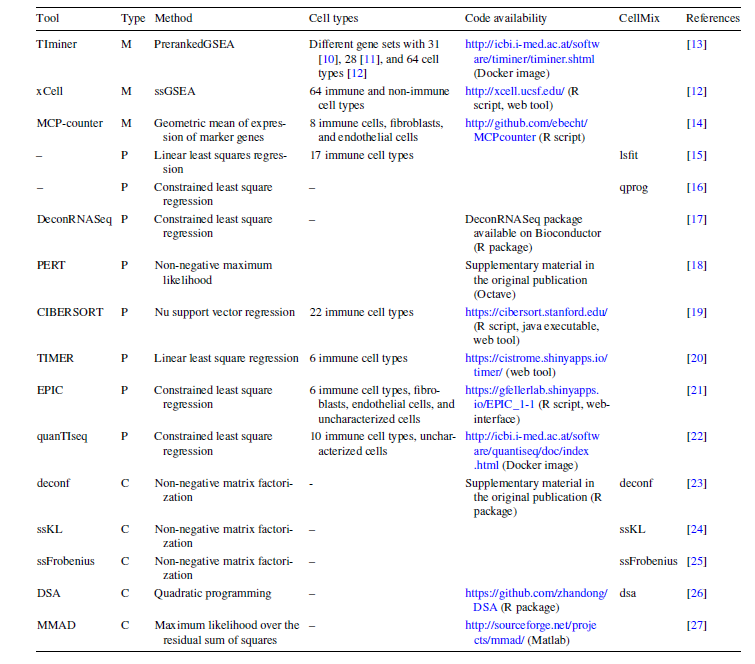

## 环境设置

使用国内镜像安装包

```r
options("repos"= c(CRAN="https://mirrors.tuna.tsinghua.edu.cn/CRAN/"))
options(BioC_mirror="http://mirrors.ustc.edu.cn/bioc/")
BiocManager::install("GSVA")
install.packages("circlize")
```

加载包

```r
library(GSVA)
library(TCGAbiolinks)
```

```r
library(ComplexHeatmap)
library(dplyr)
library(stringr)
library(rtracklayer)
library(SummarizedExperiment)
library(clusterProfiler)
library(RColorBrewer)
library(maftools)
library(circlize)
library(matrixStats)
library(GetoptLong)
library(GenomicRanges)
Sys.setenv(LANGUAGE = "en") #显示英文报错信息
options(stringsAsFactors = FALSE) #禁止chr转成factor
```

## 输入数据预处理

用ssGSEA量化免疫浸润，需要两个输入数据：

- easy_input_immunity.rdata，24种免疫细胞marker genes的ENTREZ ID，保存为list。来源：[2013 Immunity那篇文章的Table S1](https://www.cell.com/cms/10.1016/j.immuni.2013.10.003/attachment/8dc04d32-6aff-4eda-99f5-6401bcae9751/mmc1.pdf)，手动整理成csv格式，并用GPL96（HG-U133A Affymetrix platform）按照探针得到gene symbol，文章有提到这批数据是从这个芯片平台得到的。
- easy_input_expr.csv，基因表达矩阵，每行一个基因，每列一个sample。第一列基因ID跟easy_input_immunity.rdata里的基因ID一致，此处都用ENTREZ ID。文件太大，请从微云下载easy_input_expr.csv和not_easy_input_expr.csv：https://share.weiyun.com/5EsD2Ek

**如果你已经准备好了这两个文件，就可以直接进入“用ssGSEA来量化浸润水平”。**

下面带你获得这两个输入文件：

### 免疫细胞marker genes

这步获得的easy_input_immunity.rdata里面是各种免疫细胞marker genes list，可重复使用。

```r
# 读入免疫细胞marker genes
immunity <- read.csv("immunitygene.csv", header = T)

# 去除不是免疫细胞的CellType
immunity <- immunity[!immunity$CellType %in% c("Blood vessels", "Normal mucosa", "SW480 cancer cells", "Lymph vessels"), ]

# 转成list，去除冗余基因
# 文献marker genes是在affy芯片平台上获取的，我这里选用的是Entrez_ID。也可以用Gene symbol
immunity <- immunity %>%
  split(., .$CellType) %>%
  lapply(., function(x)(x$ENTREZ_GENE_ID))
immunity <- lapply(immunity, unique)

# 保存到文件，便于过后重复使用时直接读取
save(immunity,file = "easy_input_immunity.rdata")
```

### 表达矩阵

TCGA表达数据的获取方式：

- 用TGCAbiolinks下载表达数据read count，然后转成TPM，数据下载和转换的方法可参考FigureYa23count2TPM；第一列是ENTREZ ID，其后每列一个sample。需要把gene_id换成gene symbol或ENTREZ ID。GDC来源的TCGA数据用的是v22版本，从GENCODEhttps://www.gencodegenes.org/进去，点击下载v22版本gtf文件：ftp://ftp.ebi.ac.uk/pub/databases/gencode/Gencode_human/release_22/gencode.v22.annotation.gtf.gz
- 或者下载所有癌症的TPM，提取感兴趣癌症的TPM，可参考FigureYa56immune_inflitrationV2。

此处用TGCAbiolinks下载“TCGA-COAD”和“TCGA-READ”的基因表达矩阵，然后转成TPM，获得not_easy_input_expr.txt文件。

如果你已经生成过gtf_v22.csv文件，就可以跳过下面这段。

```r
# 先获得protein_coding gene的gene_id跟gene symbol的对应关系
gtf_v22 <- rtracklayer::import("gencode.v22.annotation.gtf")
gtf_v22 <- as.data.frame(gtf_v22)
gtf_v22 <- dplyr::select(gtf_v22, c("gene_id", "gene_type", "gene_name")) %>%
  filter(., gene_type ==  "protein_coding") %>%
  unique()
gtf_v22 <- gtf_v22[!duplicated(gtf_v22), ]

# 再加入ENTREZ ID，如果immunity.rdata里用的是gene symbol，就不需要运行下面这行
gtf_v22 <- bitr(gtf_v22$gene_name, fromType = "SYMBOL", toType = "ENTREZID", OrgDb = "org.Hs.eg.db") %>%
  merge(., gtf_v22, by.x = "SYMBOL", by.y = "gene_name") %>%
  mutate(., gene_id = str_sub(gene_id, 1, 15))

# 这步获得gtf_v22.csv文件，包含v22版本protein_coding gene的gene_id、gene symbol和ENTREZ ID的对应关系，可重复使用。
write.csv(gtf_v22, "gtf_v22.csv", quote = F, row.names = F)
```

把gene_id换成ENTREZ ID

```r
tcga_expr <- read.csv("not_easy_input_expr.csv", header = T, stringsAsFactors = F, row.names = 1)
tcga_expr[1:3,1:3]

gtf_v22 <- read.csv("gtf_v22.csv")

library(data.table)
tcga_expr <- merge(gtf_v22[, c("ENTREZID", "gene_id")], tcga_expr, by.x = 2, by.y = 0) %>% .[, -1] %>%
    aggregate(.~ENTREZID, ., median) #这步运行时间长
rownames(tcga_expr) <- tcga_expr$ENTREZID
tcga_expr <- tcga_expr[, -1]
head(tcga_expr)
# 保存到文件
write.csv(round(tcga_expr,1), "easy_input_expr.csv", quote = F)
```

## 用ssGSEA来量化浸润水平

```r
tcga_expr <- read.csv("easy_input_expr.csv", row.names = 1)
tcga_expr[1:3,1:2]
```

```
##   TCGA.AZ.4315.01A.01R.1410.07 TCGA.AA.3667.01A.01R.0905.07
## 1                          0.0                          0.1
## 2                         73.8                         57.7
## 9                         23.9                          3.6
```

```r
(load("easy_input_immunity.rdata"))
```

```
## [1] "immunity"
```

```r
immunity[1]
```

```
## $aDC
## [1] 27074  6346  3620  4940 10148
```

```r
# 下面这一句就完成了ssGSEA
tcga_gsva <- as.data.frame(t(gsva(as.matrix(tcga_expr), immunity, method = "ssgsea")))
```

```
## Estimating ssGSEA scores for 24 gene sets.
##
##
```

```r
str(tcga_gsva)
```

```
## 'data.frame':    644 obs. of  24 variables:
##  $ aDC                : num  0.0831 0.00772 0.09695 0.25453 0.05332 ...
##  $ B cells            : num  -0.184 -0.206 -0.203 -0.147 -0.198 ...
##  $ CD8 T cells        : num  0.294 0.257 0.262 0.33 0.269 ...
##  $ Cytotoxic cells    : num  0.0543 0.0146 -0.0169 0.2026 -0.097 ...
##  $ DC                 : num  -0.0817 -0.0182 -0.1056 0.0335 -0.0903 ...
##  $ Eosinophils        : num  0.0576 0.113 0.0665 0.0908 0.0895 ...
##  $ iDC                : num  0.133 0.1241 0.0854 0.1243 0.0819 ...
##  $ Macrophages        : num  0.1546 0.0924 0.1266 0.2032 0.1233 ...
##  $ Mast cells         : num  -0.133 -0.144 -0.16 -0.114 -0.115 ...
##  $ Neutrophils        : num  -0.1278 0.0227 -0.1012 -0.0417 -0.0773 ...
##  $ NK CD56bright cells: num  -0.02717 0.19874 0.00336 0.04345 -0.02077 ...
##  $ NK CD56dim cells   : num  0.0558 0.1467 0.1377 0.0715 0.0778 ...
##  $ NK cells           : num  0.133 0.188 0.153 0.148 0.118 ...
##  $ pDC                : num  0.0808 0.1537 0.3144 0.1053 0.1795 ...
##  $ T cells            : num  -0.02109 -0.01968 0.00265 0.18272 0.00267 ...
##  $ T helper cells     : num  0.295 0.193 0.281 0.309 0.315 ...
##  $ Tcm                : num  0.00342 0.02334 0.06001 0.03764 0.05984 ...
##  $ Tem                : num  0.111 0.184 0.182 0.136 0.154 ...
##  $ TFH                : num  -0.05815 0.00412 -0.03212 0.0198 -0.04805 ...
##  $ Tgd                : num  -0.0524 -0.1538 -0.0349 -0.051 -0.0603 ...
##  $ Th1 cells          : num  0.00458 0.02521 0.01387 0.0526 0.00224 ...
##  $ Th17 cells         : num  -0.0432 0.1729 -0.0493 0.0508 -0.0535 ...
##  $ Th2 cells          : num  0.0926 -0.0302 0.0393 0.0639 0.057 ...
##  $ TReg               : num  -0.10151 -0.00888 -0.08297 0.02634 -0.16694 ...
```

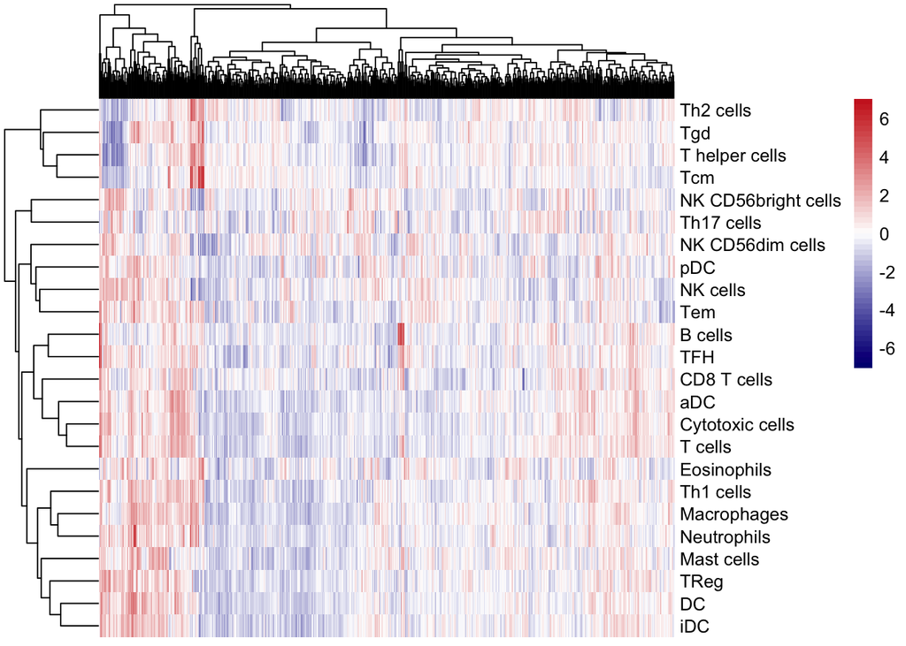

```r
# 把ssGSEA结果保存到文件
write.csv(tcga_gsva, "ssGSEA_output.csv", quote = F, row.names = T)

# 画个图粗略看一下结果
library(pheatmap)
pheatmap(t(tcga_gsva), scale = "row", show_colnames = F, color = colorRampPalette(c("navy", "white", "firebrick3"))(50))
```

如果你只想计算免疫浸润，那么到这里就结束了。

如果你想把免疫浸润跟突变、临床信息结合起来看，复现例文的原图，就需要运行下面这部分：

## 原图复现

下面用TCGAbiolink从GDC下载数据，需要找个网络好点的地方。

### 下载突变信息

变异类型归为WT和Mutant，参考 https://bioconductor.org/packages/devel/bioc/vignettes/ELMER/inst/doc/pipe.html

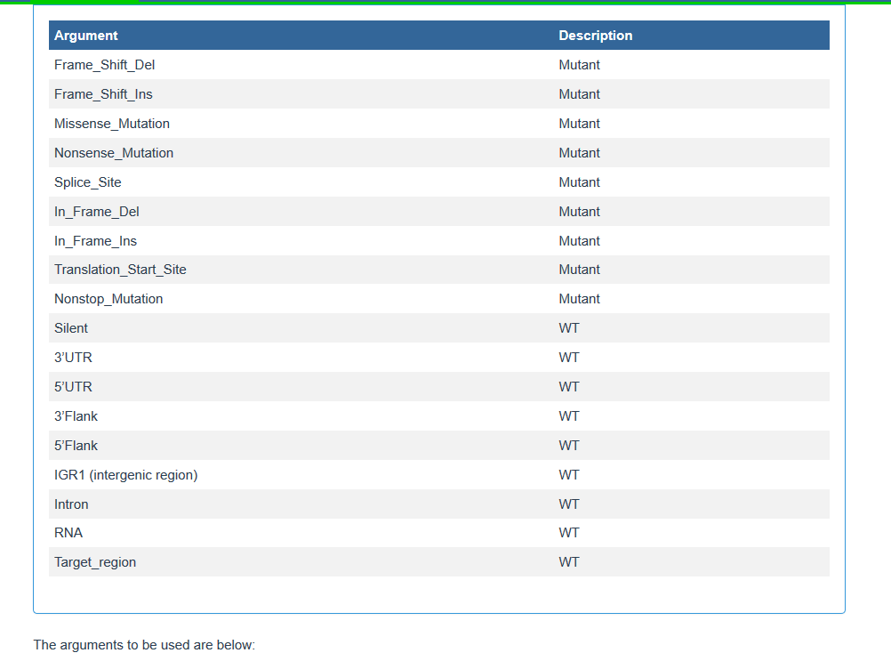

```r
targetMut <- c("TP53", "KRAS", "BRAF", "EGFR") #提取哪个基因的突变
nonsilentmutation <- c("Frame_Shift_Del", "Frame_Shift_Ins", "Missense_Mutation", "Nonsense_Mutation", "Splice_Site", "In_Frame_Del", "In_Frame_Ins", "Translation_Start_Site", "Nonstop_Mutation") #Splice_Region是ncRNA-splicing

# 4种找mutation的pipeline任选其一：muse, varscan2, somaticsniper, mutect2
#此处提取COAD和READ的突变信息
coadmut <- GDCquery_Maf(tumor = "COAD", pipelines = "varscan2")
```

```
##  For more information about MAF data please read the following GDC manual and web pages:
```

```
##  GDC manual: https://gdc-docs.nci.nih.gov/Data/PDF/Data_UG.pdf
```

```
##  https://gdc-docs.nci.nih.gov/Data/Bioinformatics_Pipelines/DNA_Seq_Variant_Calling_Pipeline/
```

```
##  https://gdc.cancer.gov/about-gdc/variant-calling-gdc
```

```
## o GDCquery: Searching in GDC database
```

```
## Genome of reference: hg38
```

```
## oo Accessing GDC. This might take a while...
```

```
## ooo Project: TCGA-COAD
```

```
## oo Filtering results
```

```
## ooo By access
```

```
## ooo By data.type
```

```
## ooo By workflow.type
```

```
## oo Checking data
```

```
## ooo Check if there are duplicated cases
```

```
## ooo Check if there results for the query
```

```
## o Preparing output
```

```
## Of the 1 files for download 1 already exist.
```

```
## All samples have been already downloaded
```

```r
readmut <- GDCquery_Maf(tumor = "READ", pipelines = "varscan2")
```

```
##  For more information about MAF data please read the following GDC manual and web pages:
```

```
##  GDC manual: https://gdc-docs.nci.nih.gov/Data/PDF/Data_UG.pdf
```

```
##  https://gdc-docs.nci.nih.gov/Data/Bioinformatics_Pipelines/DNA_Seq_Variant_Calling_Pipeline/
```

```
##  https://gdc.cancer.gov/about-gdc/variant-calling-gdc
```

```
## o GDCquery: Searching in GDC database
```

```
## Genome of reference: hg38
```

```
## oo Accessing GDC. This might take a while...
```

```
## ooo Project: TCGA-READ
```

```
## oo Filtering results
```

```
## ooo By access
```

```
## ooo By data.type
```

```
## ooo By workflow.type
```

```
## oo Checking data
```

```
## ooo Check if there are duplicated cases
```

```
## ooo Check if there results for the query
```

```
## o Preparing output
```

```
## Of the 1 files for download 1 already exist.
```

```
## All samples have been already downloaded
```

```r
all(colnames(coadmut) == colnames(readmut)) #两个文件的列名都是一样的，可以直接合并
```

```
## [1] TRUE
```

```r
crcmut <- rbind(coadmut, readmut)
crcmut <- data.frame(sample = str_sub(crcmut$Tumor_Sample_Barcode, 1, 12), crcmut)
all_mutSample <- unique(crcmut$sample)

# 去除Silent mutations
table(crcmut$Variant_Classification)
```

```
##
##                3'Flank                  3'UTR                5'Flank
##                   1912                  21975                   1696
##                  5'UTR        Frame_Shift_Del        Frame_Shift_Ins
##                   6189                  17423                   4773
##                    IGR           In_Frame_Del           In_Frame_Ins
##                     29                   1349                    134
##                 Intron      Missense_Mutation      Nonsense_Mutation
##                  12993                 152545                  13319
##       Nonstop_Mutation                    RNA                 Silent
##                    122                   4427                  56516
##          Splice_Region            Splice_Site Translation_Start_Site
##                   2746                   3070                    175
```

```r
crcmut <- crcmut[crcmut$Variant_Classification %in% nonsilentmutation, ]

# 提取target gene的突变
crc_mut_gene <- crcmut[crcmut$Hugo_Symbol %in% targetMut,]

TP53mutSample <- unique(crc_mut_gene[crc_mut_gene$Hugo_Symbol == "TP53", "sample"])  #带有目标突变的sample
TP53wildSample <- setdiff(all_mutSample, TP53mutSample) #文件中的其他sample被认为是野生型，不在该文件中的sample被认为是未检出，后面将被标为NA

KRASmutSample <- unique(crc_mut_gene[crc_mut_gene$Hugo_Symbol == "KRAS", "sample"])
KRASwildSample <- setdiff(all_mutSample, KRASmutSample)

BRAFmutSample <- unique(crc_mut_gene[crc_mut_gene$Hugo_Symbol == "BRAF", "sample"])
BRAFwildSample <- setdiff(all_mutSample, BRAFmutSample)

EGFRmutSample <- unique(crc_mut_gene[crc_mut_gene$Hugo_Symbol == "EGFR", "sample"])
EGFRwildSample <- setdiff(all_mutSample, EGFRmutSample)
```

### 下载msi临床信息

```r
msiquery1 <- GDCquery(project = "TCGA-COAD",
                  data.category = "Other",
                  legacy = TRUE,
                  access = "open",
                  data.type = "Auxiliary test")
```

```
## o GDCquery: Searching in GDC database
```

```
## Genome of reference: hg19
```

```
## oo Accessing GDC. This might take a while...
```

```
## ooo Project: TCGA-COAD
```

```
## oo Filtering results
```

```
## ooo By access
```

```
## ooo By data.type
```

```
## oo Checking data
```

```
## ooo Check if there are duplicated cases
```

```
## ooo Check if there results for the query
```

```
## o Preparing output
```

```r
GDCdownload(msiquery1)
```

```
## Of the 436 files for download 436 already exist.
```

```
## All samples have been already downloaded
```

```r
coad_msi_results <- GDCprepare_clinic(msiquery1, "msi")
msiquery2 <- GDCquery(project = "TCGA-READ",
                  data.category = "Other",
                  legacy = TRUE,
                  access = "open",
                  data.type = "Auxiliary test")
```

```
## o GDCquery: Searching in GDC database
```

```
## Genome of reference: hg19
```

```
## oo Accessing GDC. This might take a while...
```

```
## ooo Project: TCGA-READ
```

```
## oo Filtering results
```

```
## ooo By access
```

```
## ooo By data.type
```

```
## oo Checking data
```

```
## ooo Check if there are duplicated cases
```

```
## ooo Check if there results for the query
```

```
## o Preparing output
```

```r
GDCdownload(msiquery2)
```

```
## Of the 162 files for download 162 already exist.
```

```
## All samples have been already downloaded
```

```r
read_msi_results <- GDCprepare_clinic(msiquery2, "msi")
msi_results <- rbind(read_msi_results, coad_msi_results) %>% .[, c(1, 3)]
colnames(msi_results) <- c("sample", "MSI")
```

### 下载其他临床信息

```r
coadclinical <- GDCquery(project = "TCGA-COAD",
                  data.category = "Clinical",
                  file.type = "xml")
```

```
## o GDCquery: Searching in GDC database
```

```
## Genome of reference: hg38
```

```
## oo Accessing GDC. This might take a while...
```

```
## ooo Project: TCGA-COAD
```

```
## oo Filtering results
```

```
## ooo By file.type
```

```
## oo Checking data
```

```
## ooo Check if there are duplicated cases
```

```
## ooo Check if there results for the query
```

```
## o Preparing output
```

```r
GDCdownload(coadclinical)
```

```
## Of the 524 files for download 524 already exist.
```

```
## All samples have been already downloaded
```

```r
coadclinical <- GDCprepare_clinic(coadclinical, clinical.info = "patient")
```

```
## To get the following information please change the clinical.info argument
```

```
## => new_tumor_events: new_tumor_event
## => drugs: drug
## => follow_ups: follow_up
## => radiations: radiation
```

```
## Parsing follow up version: follow_up_v1.0
```

```
## Adding stage event information
```

```r
readclinical <- GDCquery(project = "TCGA-READ",
                  data.category = "Clinical",
                  file.type = "xml")
```

```
## o GDCquery: Searching in GDC database
```

```
## Genome of reference: hg38
```

```
## oo Accessing GDC. This might take a while...
```

```
## ooo Project: TCGA-READ
```

```
## oo Filtering results
```

```
## ooo By file.type
```

```
## oo Checking data
```

```
## ooo Check if there are duplicated cases
```

```
## ooo Check if there results for the query
```

```
## o Preparing output
```

```r
GDCdownload(readclinical)
```

```
## Of the 186 files for download 186 already exist.
```

```
## All samples have been already downloaded
```

```r
readclinical <- GDCprepare_clinic(readclinical, clinical.info = "patient")
```

```
## To get the following information please change the clinical.info argument
```

```
## => new_tumor_events: new_tumor_event
## => drugs: drug
## => follow_ups: follow_up
## => radiations: radiation
```

```
## Parsing follow up version: follow_up_v1.0
```

```
## Adding stage event information
```

```r
all(colnames(readclinical) == colnames(coadclinical))
```

```
## [1] TRUE
```

```r
clinical <- rbind(coadclinical, readclinical)
```

### 组合所需要的临床信息

```r
targetAnno <- clinical[, c("bcr_patient_barcode", "stage_event_pathologic_stage", "gender", "vital_status", "anatomic_neoplasm_subdivision", "colon_polyps_present" )]
table(targetAnno$anatomic_neoplasm_subdivision)
```

```
##
##                             Ascending Colon                 Cecum
##                    25                   102                   123
##      Descending Colon       Hepatic Flexure Rectosigmoid Junction
##                    24                    29                    54
##         Sigmoid Colon       Splenic Flexure      Transverse Colon
##                   178                     9                    42
##                Rectum
##                   124
```

```r
#从盲肠到横结肠为右侧，从脾曲到直肠为左侧结直肠癌
targetAnno$tumor_site <- targetAnno$anatomic_neoplasm_subdivision %>%
  str_replace(., "(Cecum|Ascending Colon|Hepatic Flexure|Transverse Colon)", "right") %>%
  str_replace(., "(Splenic Flexure|Descending Colon|Sigmoid Colon|Rectosigmoid Junction|Rectum)", "left")
targetAnno <- merge(targetAnno, msi_results, by.x = "bcr_patient_barcode", by.y = "sample",all.x = T)
targetAnno$TP53mut <- NA
targetAnno$KRASmut <- NA
targetAnno$BRAFmut <- NA
targetAnno$EGFRmut <- NA

targetAnno[targetAnno$bcr_patient_barcode %in% TP53mutSample, "TP53mut"] <- "mutant"
targetAnno[targetAnno$bcr_patient_barcode %in% TP53wildSample, "TP53mut"] <- "wildtype"

targetAnno[targetAnno$bcr_patient_barcode %in% KRASmutSample, "KRASmut"] <- "mutant"
targetAnno[targetAnno$bcr_patient_barcode %in% KRASwildSample, "KRASmut"] <- "wildtype"

targetAnno[targetAnno$bcr_patient_barcode %in% BRAFmutSample, "BRAFmut"] <- "mutant"
targetAnno[targetAnno$bcr_patient_barcode %in% BRAFwildSample, "BRAFmut"] <- "wildtype"

targetAnno[targetAnno$bcr_patient_barcode %in% EGFRmutSample, "EGFRmut"] <- "mutant"
targetAnno[targetAnno$bcr_patient_barcode %in% EGFRwildSample, "EGFRmut"] <- "wildtype"

summary(targetAnno)
```

```
##  bcr_patient_barcode stage_event_pathologic_stage    gender
##  Length:710          Stage IIA :198               FEMALE:326
##  Class :character    Stage I   :121               MALE  :383
##  Mode  :character    Stage IIIB: 96                     :  1
##                      Stage IV  : 78
##                      Stage IIIC: 61
##                      Stage II  : 46
##                      (Other)   :110
##  vital_status       anatomic_neoplasm_subdivision colon_polyps_present
##       :  2    Sigmoid Colon        :178              :381
##  Alive:633    Rectum               :124           NO :224
##  Dead : 75    Cecum                :123           YES:105
##               Ascending Colon      :102
##               Rectosigmoid Junction: 54
##               Transverse Colon     : 42
##               (Other)              : 87
##   tumor_site                   MSI        TP53mut
##  Length:710         Indeterminate:  4   Length:710
##  Class :character   MSI-H        : 98   Class :character
##  Mode  :character   MSI-L        :111   Mode  :character
##                     MSS          :459
##                     NA's         : 38
##
##
##    KRASmut            BRAFmut            EGFRmut
##  Length:710         Length:710         Length:710
##  Class :character   Class :character   Class :character
##  Mode  :character   Mode  :character   Mode  :character
##
##
##
##
```

### 融合ssGSEA和临床表达数据

```r
tcga_gsva <- read.csv("ssGSEA_output.csv", row.names = 1)
tcga_gsva <- data.frame(sample = str_sub(rownames(tcga_gsva), 1, 12), barcode = rownames(tcga_gsva), tcga_gsva)
tcga_gsva$sample <- str_replace_all(tcga_gsva$sample, "\\.", "-")

library(data.table)
```

```r
heatmapinput <- unique(merge(tcga_gsva, targetAnno, by.x = "sample", by.y = "bcr_patient_barcode", all.x = T))
library(data.table)
rownames(heatmapinput) <- heatmapinput$barcode
summary(heatmapinput)
```

```
##     sample            barcode               aDC
##  Length:644         Length:644         Min.   :-0.229630
##  Class :character   Class :character   1st Qu.:-0.062474
##  Mode  :character   Mode  :character   Median : 0.003737
##                                        Mean   : 0.014025
##                                        3rd Qu.: 0.074706
##                                        Max.   : 0.346807
##
##     B.cells         CD8.T.cells     Cytotoxic.cells          DC
##  Min.   :-0.2870   Min.   :0.2096   Min.   :-0.23493   Min.   :-0.29689
##  1st Qu.:-0.2234   1st Qu.:0.2690   1st Qu.:-0.08732   1st Qu.:-0.13134
##  Median :-0.2007   Median :0.2799   Median :-0.03312   Median :-0.08392
##  Mean   :-0.1919   Mean   :0.2817   Mean   :-0.01899   Mean   :-0.06915
##  3rd Qu.:-0.1722   3rd Qu.:0.2942   3rd Qu.: 0.03549   3rd Qu.:-0.01732
##  Max.   : 0.1458   Max.   :0.3518   Max.   : 0.33239   Max.   : 0.32023
##
##   Eosinophils           iDC            Macrophages
##  Min.   :0.00574   Min.   :-0.05325   Min.   :-0.05836
##  1st Qu.:0.06680   1st Qu.: 0.06250   1st Qu.: 0.07894
##  Median :0.08353   Median : 0.09268   Median : 0.12387
##  Mean   :0.08559   Mean   : 0.09698   Mean   : 0.13397
##  3rd Qu.:0.10251   3rd Qu.: 0.13007   3rd Qu.: 0.18167
##  Max.   :0.18571   Max.   : 0.31179   Max.   : 0.38806
##
##    Mast.cells        Neutrophils       NK.CD56bright.cells
##  Min.   :-0.27830   Min.   :-0.23904   Min.   :-0.13189
##  1st Qu.:-0.15726   1st Qu.:-0.13179   1st Qu.: 0.03086
##  Median :-0.11738   Median :-0.08804   Median : 0.07119
##  Mean   :-0.11503   Mean   :-0.07865   Mean   : 0.07586
##  3rd Qu.:-0.07878   3rd Qu.:-0.04277   3rd Qu.: 0.11266
##  Max.   : 0.13710   Max.   : 0.36213   Max.   : 0.29265
##
##  NK.CD56dim.cells      NK.cells            pDC
##  Min.   :-0.11779   Min.   :0.04574   Min.   :-0.2392
##  1st Qu.: 0.02245   1st Qu.:0.12526   1st Qu.: 0.0861
##  Median : 0.05045   Median :0.14300   Median : 0.1785
##  Mean   : 0.05154   Mean   :0.14387   Mean   : 0.1930
##  3rd Qu.: 0.08533   3rd Qu.:0.16097   3rd Qu.: 0.2821
##  Max.   : 0.19031   Max.   :0.23848   Max.   : 0.6509
##
```

[output cut: 41 more lines]

```
##  Length:644         Indeterminate:  3   Length:644
##  Class :character   MSI-H        : 87   Class :character
##  Mode  :character   MSI-L        : 98   Mode  :character
##                     MSS          :405
##                     NA's         : 51
##
##
##    KRASmut            BRAFmut            EGFRmut
##  Length:644         Length:644         Length:644
##  Class :character   Class :character   Class :character
##  Mode  :character   Mode  :character   Mode  :character
##
##
##
##
```

```r
write.csv(heatmapinput, "heatmapinput.csv")
```

### 开始画图

用complexheatmap画图。complexheatmap的参数众多，有兴趣了解的详情https://bioconductor.org/packages/release/bioc/html/ComplexHeatmap.html

```r
heatmapinput <- read.csv("heatmapinput.csv", row.names = 1)
ml <- heatmapinput[, c(3:26)] #画图的ssGSEA数据
ml <- as.data.frame(t(apply(ml, 2, scale))) #scale标化
colnames(ml) <- rownames(heatmapinput)

col_fun <- colorRamp2(c(-5, 0, 5), c("#377EB8", "white", "#E41A1C"))

#获取聚类分组信息
h1 <- Heatmap(ml, cluster_rows = TRUE, cluster_columns = TRUE, clustering_method_columns = "ward.D2",show_row_names = TRUE, show_column_names = FALSE,
              clustering_distance_columns = "euclidean",
              clustering_distance_rows = "euclidean",
              clustering_method_rows  = "ward.D2")
tree <- column_dend(h1)
ind <- cutree(as.hclust(tree), k = 2)[order.dendrogram(tree)] #此处划分为2类，根据你自己的数据调整
table(ind)
```

```
## ind
##   1   2
## 217 427
```

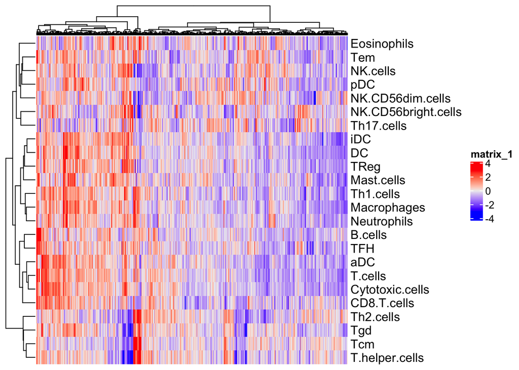

```r
heatmapinput$Immune_infiltration <- ind[heatmapinput$barcode]
draw(h1)
```

```r
heatmapinput$Immune_infiltration <- str_replace(heatmapinput$Immune_infiltration, "1", "Low infiltration")
heatmapinput$Immune_infiltration <- str_replace(heatmapinput$Immune_infiltration, "2", "High infiltration")

#临床信息注释
Immune_infiltration <- heatmapinput[, "Immune_infiltration"]
Tumor_site <- heatmapinput[, "tumor_site"]
TP53_mutation <- heatmapinput[, "TP53mut"]
KRAS_mutation <- heatmapinput[, "KRASmut"]
BRAF_mutation <- heatmapinput[, "BRAFmut"]
EGFR_mutation <- heatmapinput[, "EGFRmut"]
Gender <- heatmapinput[, "gender"]
MSI <- heatmapinput[, "MSI"]
Polyps <- heatmapinput[, "colon_polyps_present"]
Survival <- heatmapinput[, "vital_status"] #这种生存信息是没有什么价值的，建议用生存状态加时间，详细画法可以参考complexheatmap
Anatomic_location <- heatmapinput[, "anatomic_neoplasm_subdivision"]
Stage <- heatmapinput[, "stage_event_pathologic_stage"]
ha = HeatmapAnnotation(Immune_infiltration =Immune_infiltration, Tumor_site = Tumor_site,
                       TP53_mutation = TP53_mutation, KRAS_mutation = KRAS_mutation,
                       BRAF_mutation = BRAF_mutation, EGFR_mutation = EGFR_mutation,
                       Gender = Gender, MSI = MSI, Polyps = Polyps,
                       Survival = Survival, Anatomic_location = Anatomic_location,
                       Stage = Stage, show_annotation_name = FALSE,
                       col = list(Immune_infiltration = c("High infiltration" = "#3FA538",
                                                          "Low infiltration" = "#9FD29BFF"),
                         Tumor_site = c("left" = "#E00115", "right" = "#5E84B6"),
                         TP53_mutation = c("mutant" = "black", "wildtype" = "grey"),
                         KRAS_mutation = c("mutant" = "black", "wildtype" = "grey"),
                         BRAF_mutation = c("mutant" = "black", "wildtype" = "grey"),
                         EGFR_mutation = c("mutant" = "black", "wildtype" = "grey"),
                         Gender = c("MALE" = "#C4868E", "FEMALE" = "#97A8C7"),
                         MSI = c("MSI-H" = "#E5554D", "MSI-L" = "#C4868E",
                                 "MSS" = "#AEB6CE", "Indeterminate" = "#2B3D44"),
                         Polyps = c("YES" = "black", "NO" = "grey"),
                         Survival = c("Alive" = "#3FA538", "Dead" = "#E00115"),
                         Stage =  c("Stage I" = "#B0B0FFFF", "Stage IA" = "#6060FFFF", "Stage II" = "#B0FFB0FF" ,
                                    "Stage IIA" ="#95FF95FF", "Stage IIB" = "#7AFF7AFF", "Stage IIC" = "#60FF60FF",
                                    "Stage III" = "#F7E897FF", "Stage IIIA" = "#F9EF64FF",
                                    "Stage IIIB" = "#FCF732FF", "Stage IIIC" = "#FFFF00FF",
                                    "Stage IV" = "#FF6060FF", "Stage IVA"="#FF3030FF" ,
                                    "Stage IVB" = "#FF0000FF")),
                       na_col = "white", #各个临床信息的颜色，Anatomic_location颜色输入也同其他，更好颜色搭配信息请参考FigureYa28color
                       show_legend = rep(TRUE, 12),#是否要显示annotation legend
                       annotation_height = unit(rep(5, 12), "mm"),#临床annotation的高度
                       annotation_legend_param = list(
                         Immune_infiltration = list(title = "Immune infiltration"),
                         Tumor_site = list(title = "Tumor site"),
                         TP53_mutation = list(title = "TP53 mutation"),
                         KRAS_mutation = list(title = "KRAS mutation"),
                         BRAF_mutation = list(title = "BRAF mutation"),
                         EGFR_mutation = list(title = "EGFR mutation"),
                         Gender = list(title = "Gender"),
                         MSI = list(title = "MSI"),
                         Polyps = list(title = "Polyps"),
                         Survival = list(title = "Survival"),
                         Anatomic_location = list(title = "Anatomic location"),
                         Stage = list(title = "Stage"))#annotation legend的标签
)

ht <- Heatmap(ml, col = col_fun,
              name = "CRC ssGSEA",
              cluster_rows = TRUE, cluster_columns = TRUE,
              show_row_names = TRUE, show_column_names = FALSE,
              bottom_annotation = ha, column_title = qq("TCGA CRC samples (n = @{ncol(ml)})"),
              clustering_method_columns = "ward.D2",
              clustering_distance_columns = "euclidean",
              clustering_distance_rows = "euclidean",
              clustering_method_rows  = "ward.D2", column_dend_height = unit(30, "mm")
              )
pdf("ssGSEA.pdf", 16, 12)
draw(ht, annotation_legend_side = "left", heatmap_legend_side = "left")

#装饰heatmap
annotation_titles <- c(Immune_infiltration = "Immune infiltration",
                      Tumor_site = "Tumor site",
                      TP53_mutation = "TP53 mutation",
                      KRAS_mutation = "KRAS mutation",
                      BRAF_mutation = "BRAF mutation",
                      EGFR_mutation = "EGFR mutation",
                      Gender = "Gender",
                      MSI = "MSI",
                      Polyps = "Polyps",
                      Survival = "Survival",
                      Anatomic_location = "Anatomic location",
                      Stage = "Stage")
for(an in names(annotation_titles)) {
  decorate_annotation(an, {
    grid.text(annotation_titles[an], unit(-2, "mm"), just = "right")#对齐方向是右边
    grid.rect(gp = gpar(fill = NA, col = "black"))
  })
}

#分组划线：具体数值要参考聚类的信息
decorate_heatmap_body("CRC ssGSEA", {
  grid.lines(c(0, 0), c(0, 1), gp = gpar(lty = 1, lwd = 2))
  grid.lines(c(table(ind)[[1]]/sum(table(ind)), table(ind)[[1]]/sum(table(ind))),
             gp = gpar(lty = 2, lwd = 2))
  grid.lines(c(1, 1), c(0, 1), gp = gpar(lty = 1, lwd = 2))
})

#在heatmap上注释文字信息
decorate_heatmap_body("CRC ssGSEA", {
    grid.text("High infiltration", (table(ind)[[1]]/2)/sum(table(ind)), 0.1, #文字所放位置的x和y，根据自己的数据调整
              default.units = "npc", gp = gpar(fontsize = 16))
    grid.text("Low infiltration", (table(ind)[[1]] + table(ind)[[2]]/2)/sum(table(ind)), 0.1, default.units = "npc", gp = gpar(fontsize = 16))
})

dev.off()
```

[figure not shown]